# Part 2; Managing your (data) projects with ‘Guerrilla Analytics’

## A penguin wrap up

palmerpenguins

```
## # A tibble: 344 x 17
##    studyName `Sample Number` Species Region Island Stage `Individual ID`
##    <chr>               <dbl> <chr>   <chr>  <chr>  <chr> <chr>
##  1 PAL0708                 1 Adelie~ Anvers Torge~ Adul~ N1A1
##  2 PAL0708                 2 Adelie~ Anvers Torge~ Adul~ N1A2
##  3 PAL0708                 3 Adelie~ Anvers Torge~ Adul~ N2A1
##  4 PAL0708                 4 Adelie~ Anvers Torge~ Adul~ N2A2
##  5 PAL0708                 5 Adelie~ Anvers Torge~ Adul~ N3A1
##  6 PAL0708                 6 Adelie~ Anvers Torge~ Adul~ N3A2
##  7 PAL0708                 7 Adelie~ Anvers Torge~ Adul~ N4A1
##  8 PAL0708                 8 Adelie~ Anvers Torge~ Adul~ N4A2
##  9 PAL0708                 9 Adelie~ Anvers Torge~ Adul~ N5A1
## 10 PAL0708                10 Adelie~ Anvers Torge~ Adul~ N5A2
## # ... with 334 more rows, and 10 more variables: `Clutch Completion` <chr>,
## #   `Date Egg` <date>, `Culmen Length (mm)` <dbl>, `Culmen Depth (mm)` <dbl>,
## #   `Flipper Length (mm)` <dbl>, `Body Mass (g)` <dbl>, Sex <chr>, `Delta 15 N
## #   (o/oo)` <dbl>, `Delta 13 C (o/oo)` <dbl>, Comments <chr>
```

## Exploratory data Analysis - missingness

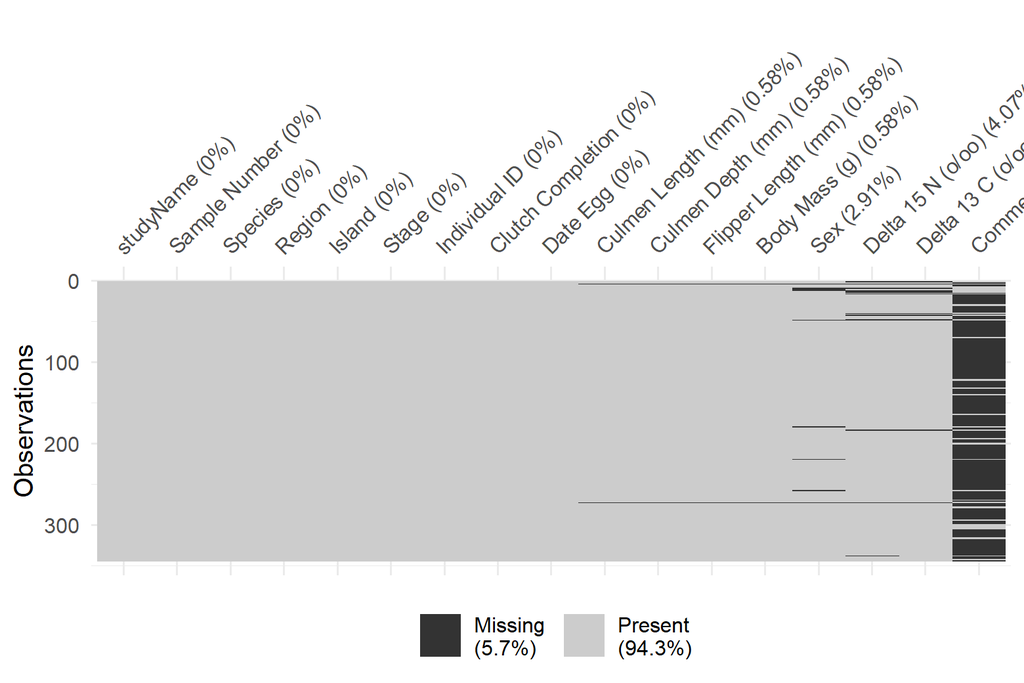

## Factor levels

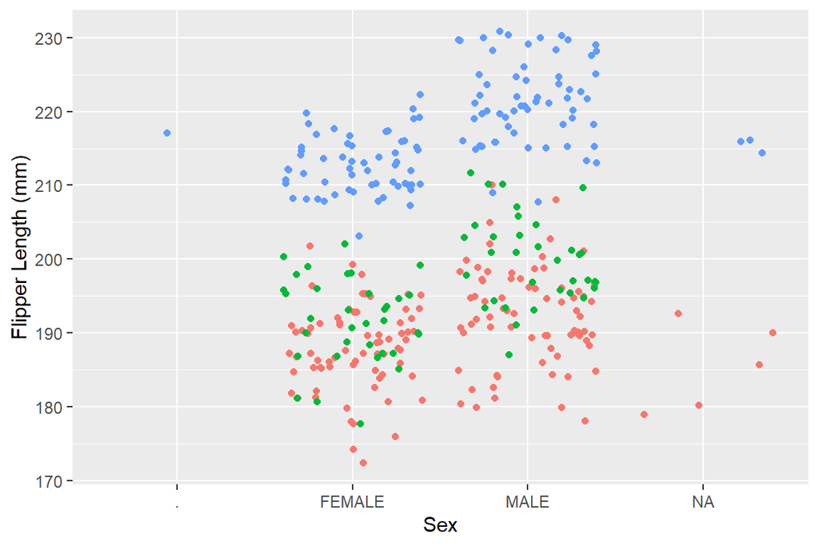

```r
data_penguins %>%
  ggplot(aes(x = Sex, y = `Flipper Length (mm)`)) +
  geom_point(aes(colour = Species), position = "jitter", show.legend = FALSE)
```

```r
unique(data_penguins$Sex) ## we also call this factor levels
```

```
## [1] "MALE"   "FEMALE" NA       "."
```

## Variable encodings

- Use explicit encoding: male/female instead of `0`/`1`
- Encodings can always be altered programmatically
- Be consistent (see next graph)
- Write a code journal that explains encodings, including units and levels
- Use factors if a variable has a set of discrete possible outcomes: `sex`, `species`, `marital_status` etc
- Use an ordered factor if there is a hiarchy in the factor levels: `year`, `month`, `number_of_legs`

## Just for kicks, one more graph

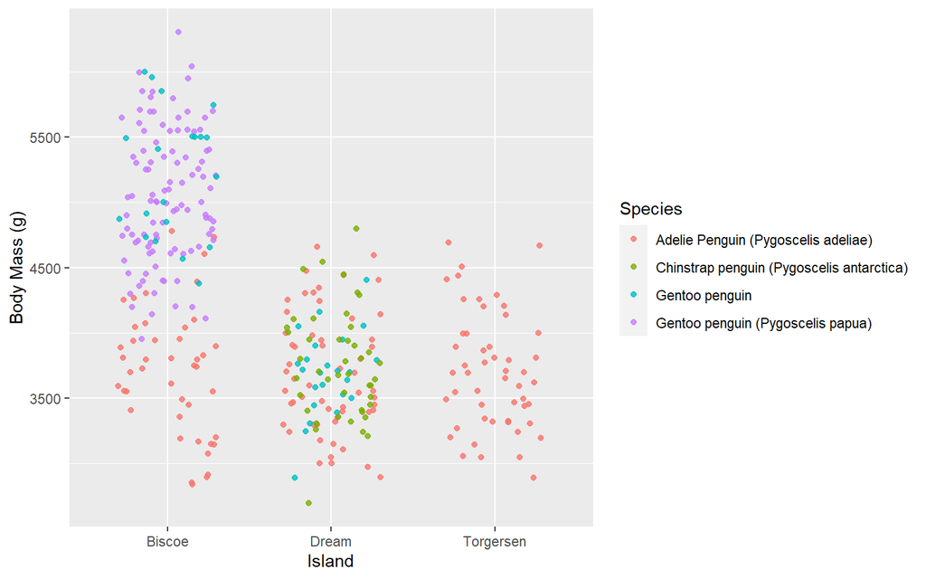

## Thank you for your attention!

[figure not shown]

**UPCOMING WEBINARS:**

Part 3; Reproducible (Open) Science @HU - Tools (July 6th, 2020)

[Peer Support Group Data Science - not live yet](https://tln.hu.nl)

[support voor onderzoek](https://bibliotheek.hu.nl/onderzoekers/)